# Descriptive Analysis Metadata

Natàlia Carreras-Gallo and Juan R. González

Barcelona Institute for Global health (ISGlobal), Barcelona, Spain  
Centro de Investigación Biomédica en Red en Epidemiología y Salud Pública (CIBERESP), Madrid, Spain  
Department of Mathematics, Universitat Autònoma de Barcelona, Bellaterra, Spain

natalia.carreras@isglobal.org  
juanr.gonzalez@isglobal.org

2022-06-29

# 1 Metadata Overview

## 1.1 Data loading

Load the required libraries and restrict the number of digits to 3:

```r
library(tidyverse)
library(knitr)
library(readxl)
library(writexl)
library(summarytools)

options(digits=3)
`%notin%` <- Negate(`%in%`)
```

Set working directory and load data:

```r
#PRBB
PatientMetaData <- read_csv("G:/TruDiagnostic/metadata/PatientMetaData_041322.csv")
PopuMetaData <- read_csv("G:/TruDiagnostic/metadata/PopulationData_031522.csv")
```

## 1.2 Data dimensions

Table 1: Number of IDs and variables for each dataset.

|  | IDs | Variables |
| --- | --- | --- |
| Patient Metadata | 4467 | 69 |
| Population metadata | 4296 | 25 |
| Intersect | 3890 | 2 |

The variables that are present in all the datasets are the PatientID (individual code for each idat file) and PID (individual code for each participant). These variables will help us to join the information from different datasets. In particular, we are interested in all the variables from the Patient Metadata and 4 variables (Decimal Chronological Age, Collection Date, Date of Birth, and Telomere Values) from the Population Metadata.

First, we create a new object (metadata) where we include the individuals that have Patient Metadata and Population Metadata.

```r
metadata <- PatientMetaData[PatientMetaData$PatientID%in%PopuMetaData$PatientID,]
```

Second, we include the 4 variables from the Population Metadata in this dataset.

```r
metadata <- merge(metadata,PopuMetaData[,c("PatientID","DecimalChronologicalAge","TelomereValues","CollectionDate","DateofBirth")],by="PatientID")
```

The variables contained in the metadata file are the following:

Table 2: Variables contained in the original metadata Three examples for the character strings and mean, minimum, and maximum for the numeric strings.

| Variable | Class | Examples |
| --- | --- | --- |
| PatientID | character | 101234567890_R01C01 / 123456789101_R01C01 / 204220340049_R01C01 |
| PID | numeric | 118759 (87689-125749) |
| Weight | numeric | 173 (1-15901) |
| Height | character | 5 ft, 1 in / 1 ft, 1 in / 6 ft, 4 in |
| Zip Code | character | 40503 / 89128 / 21076 |
| Birth Country | character | United States / USA / usa |
| Biological Sex | character | Female / Male / Intersex |
| Ethnicity/Ancestry | character | European or Caucasian / Asian (e.g. Chinese, Indian, Kazakh, Thai) / Latino or Hispanic; European or Caucasian; Middle Eastern or North African |
| Blood Type | character | O Negative / A Negative / O Postive |
| Cancer Diagnosis | character | No / skin cancer / melanoma |
| Genetic Variant | character | None of the above / BRCA1/BRCA2 / Im not sure |
| Cardiovascular | character | n/a / High Blood Pressure / High Cholesterol |
| Respiratory Disease | character | Asthma / Sleep Apnea / Pneumonia |
| Endocrine Disease | character | n/a / Hashimotos Thyroiditis / Prediabetes |
| Alcohol Use(times per week) | character | Once per week / On special occasions / Regularly |
| Skin & Hair | character | None / Eczema / Eczema; Loss of Hair |
| Age for Loss of Hair | numeric | 1 (0-73) |
| Gastrointestinal | character | n/a / Crohns Disease / Gastroesophageal Reflux Disease (GERD) |
| Genito-Urinary | character | n/a / Urinary Incontinence; Urinary Tract Infections (UTI) / Kidney Stones |
| Musculoskeletal | character | n/a / Gout / Osteoarthritis |
| Neuropsychological | character | n/a / Depression; Migraines / Traumatic Brain Injury (TBI) |
| Reproductive | character | n/a / Enlarged Prostate/Benign Prostate Hyperplasia (BPH) / Endometriosis |
| Immune | character | n/a / linear sclerodderma / Lupus |
| Menopause | character | No / Yes |
| Given Birth | character | No / Yes |
| Mother Nicotine Use | character | No / Yes / Unknown |
| Mother Pregnancy Complications | character | No / Yes / Unknown |
| Do you take any of the Following nutritional Supplements? | character | Digestive support: probiotic, digestive enzymes, etc.; Herbal supplements; Antioxidants: coenzyme Q10, green tree extract, resveratrol, etc.; Vitamins; Fish oil/Omega fatty acids; Minerals, calcium, i… |
| Do you take any of the following supplements or medications? | character | Resveratrol / Metformin; Dehydroepiandrosterone (DHEA) / Dehydroepiandrosterone (DHEA) |
| Actively engage in anti-aging interventions? | character | Hormone replacement therapy / Stem cell therapy; Hormone replacement therapy; NAD therapy / NAD therapy |
| Diagnosed with low or high calcium | character | No / Yes |
| Marital Status | character | Single / Separated / Divorced |
| Level of Education | character | Bachelors degree / Technical or occupational certificate / Professional (MD, DO, DDS, JD) |
| Education of Mother | character | Bachelors degree / Technical or occupational certificate / High school or equivalent |
| Education of Father | character | Bachelors degree / Technical or occupational certificate / Professional (MD, DO, DDS, JD) |
| Stress Level | numeric | 5 (1-10) |
| Caffeine Use | character | 3-5 times per week / Regularly / On special occasions |
| Tobacco Use | character | None / Less than 1 cigarette per week / 1-5 cigarettes per day |
| Pack Years (If smoker) | numeric | 489 (1-10000) |
| Recreational Drug Use? | character | None / Benzodiazepines / Marijuana |
| How often do you use recreational Drugs? | character | On special occasions / Regularly / 3-5 times per week |
| What does your diet mostly consist of? | character | Both meat and vegetables / Mostly vegetables / Mostly meat and fish |
| How often do you exercise per week? | character | 3-4 times per week / 1-2 times per week / 5-7 times per week |
| Exercise Type? | character | Endurance / Strength / Flexibility |
| Sexual Frequency? | character | Occasionally / Regular / Inactive |
| Hours of sleep per night? | character | 6 to 8 hours / 6 hours or less / More than 8 hours |
| Allergies | logical |  |
| Arthritis | character | Father, Paternal Grand-mother / Mother, Paternal Grand-mother, Paternal Grand-father / Mother, Paternal Grand-mother |
| Asthma | character | Father / Mother, Father, Son / Son |
| Back Problems | character | Father, Paternal Grand-mother / Father, Paternal Grand-father / Mother |
| Blood Diseases | character | Mother / Mother, Sister / Father |
| Cancer | character | Paternal Grand-father / Mother, Father, Sister / Mother, Maternal Grand-mother, Maternal Grand-father, Paternal Grand-father |
| COPD | character | Paternal Grand-mother, Paternal Grand-father / Mother / Maternal Grand-mother, Maternal Grand-father |
| Diabetes | character | Mother,Father,Maternal Grand-mother,Paternal Grand-mother / Maternal Grand-mother / Mother, Father |
| Drug/Alcohol | character | Brother / Maternal Grand-father / Father |
| Emphysema | character | Paternal Grand-mother, Paternal Grand-father / Mother / Maternal Grand-father |
| Genetic Disorder | character | Mother, Sister / Father / Father, Sister, Brother |
| Stomach Problems | character | Father, Paternal Grand-father, Daughter / Son / Father |
| Kidney Disease | character | Mother / Father / Maternal Grand-mother |
| Heart Problems | character | Mother, Father, Maternal Grand-father / Paternal Grand-father / Maternal Grand-mother, Paternal Grand-mother |
| High Blood Pressure | character | Mother,Father,Maternal Grand-mother,Paternal Grand-mother / Paternal Grand-father / Mother |
| Neurological Disease | character | Mother / Father, Maternal Grand-mother, Paternal Grand-father / Father |
| Obesity | character | Father, Paternal Grand-father / Father, Sister, Brother / Brother |
| Psychiatric | character | Mother / Sister / Maternal Grand-father |
| Scolliosis | character | Maternal Grand-father / Maternal Grand-mother / Mother |
| SIDS | character | Maternal Grand-mother / Brother, Maternal Grand-mother / Mother |
| Stroke | character | Father / Paternal Grand-father / Maternal Grand-father |
| Tuberculosis | character | Mother / Paternal Grand-father / Maternal Grand-father |
| Thyroid Disorder | character | Maternal Grand-mother / Mother, Paternal Grand-mother / Mother |
| DecimalChronologicalAge | numeric | 53 (2.86-97.79) |
| TelomereValues | numeric | 7 (5.93-8.43) |
| CollectionDate | character | 1/4/2022 / 12/15/2021 / 1/1/1900 |
| DateofBirth | character | 6/6/1998 / 2/2/2019 / 9/20/1963 |

## 1.3 Data transformation

First, we change the variable names by replacing the spaces ” “, slashes”/“, and dashes”-” with a low bar “_“. We also remove the question mark”?” at the end of the variable name and we change some variables for a shorter name.

```r
colnames(metadata) <- gsub(" ", "_", colnames(metadata), fixed = TRUE)
colnames(metadata) <- gsub("/", "_", colnames(metadata), fixed = TRUE)
colnames(metadata) <- gsub("-", "_", colnames(metadata), fixed = TRUE)
colnames(metadata) <- gsub("?", "", colnames(metadata), fixed = TRUE)

colnames(metadata)[which(names(metadata) == "Skin_&_Hair")] <- "Skin_Hair"
colnames(metadata)[which(names(metadata) == "Do_you_take_any_of_the_Following_nutritional_Supplements")] <- "Nutritional_Supplements"
colnames(metadata)[which(names(metadata) == "Do_you_take_any_of_the_following_supplements_or_medications")] <- "Supplements_Medication"
colnames(metadata)[which(names(metadata) == "Pack_Years_(If_smoker)")] <- "Pack_Years_Smoker"
colnames(metadata)[which(names(metadata) == "Actively_engage_in_anti-aging_interventions")] <- "Anti_Aging"
colnames(metadata)[which(names(metadata) == "How_often_do_you_use_recreational_Drugs")] <- "Recreational_Drug_Frequency"
colnames(metadata)[which(names(metadata) == "What_does_your_diet_mostly_consist_of")] <- "Main_Diet"
colnames(metadata)[which(names(metadata) == "How_often_do_you_exercise_per_week")] <- "Exercise_per_week"
colnames(metadata)[which(names(metadata) == "High_Blood_Pressure")] <- "High_Blood_pressure_parents"
colnames(metadata)[which(names(metadata) == "Alcohol_Use(times_per_week)")] <- "Alcohol_Use_per_week"
```

Second, we transform some character variables to factor and we sort the levels.

```r
metadata$Caffeine_Use <- factor(metadata$Caffeine_Use,
                levels = c("Never", "On sepecial occasions", "Once per week","3-5 times per week","Regularly"))
metadata$Tobacco_Use <- factor(metadata$Tobacco_Use,
                levels = c("None", "Less than 1 cigarette per week","Less than 1 cigarette per day", "1-5 cigarettes per day",
                           "6-10 cigarettes per day","11-20 cigarettes per day","More than 20 cigarettes per day"))
metadata$Level_of_Education <- factor(metadata$Level_of_Education,
                                      levels = c("Did not complete high school","High school or equivalent",
                                                 "Technical or occupational certificate","Associate degree",
                                                 "Some college coursework completed","Bachelors degree","Masters degree",
                                                 "Doctorate (PhD)","Professional (MD, DO, DDS, JD)"))
metadata$Recreational_Drug_Frequency <- factor(metadata$Recreational_Drug_Frequency,
                levels = c("Never","On special occasions","Once per week","3-5 times per week","Regularly"))
metadata$Exercise_per_week <- factor(metadata$Exercise_per_week,
                levels = c("Never","1-2 times per week","3-4 times per week","5-7 times per week","8 or more times per week"))
metadata$Hours_of_sleep_per_night <- factor(metadata$Hours_of_sleep_per_night,
                levels = c("5 hours or less", "6 hours or less", "More than 8 hours"))
metadata$Alcohol_Use_per_week <- factor(metadata$Alcohol_Use_per_week,
                levels = c("Never","On special occasions","Once per week","3-5 times per week","Regularly"))
```

Third, there are different variables that are codified in a difficult way to understand. We are going to code them in an easier way.

### 1.3.1 Birth country

There are a lot of birth countries that are coded in different ways but reffers to the same country. We start with these number of different countries:

```r
length(sort(unique(metadata$Birth_Country)))
```

[1] 341

First of all, we convert all the birth countries to lower case.

```r
metadata$Birth_Country <- tolower(metadata$Birth_Country)
```

Based on the answers of the participants, we group some answers:

```r
metadata[which(metadata$Birth_Country=="canada000"),]$Birth_Country <- "canada"
metadata[which(metadata$Birth_Country=="cn"),]$Birth_Country <- "china"
metadata[which(metadata$Birth_Country=="brasil"),]$Birth_Country <- "brazil"
metadata[which(metadata$Birth_Country=="columbia"),]$Birth_Country <- "colombia"
metadata[which(metadata$Birth_Country=="ecuador"),]$Birth_Country <- "equador"
metadata[which(metadata$Birth_Country=="isreal"),]$Birth_Country <- "israel"
metadata[which(metadata$Birth_Country=="south african"),]$Birth_Country <- "south africa"
metadata[which(metadata$Birth_Country=="switzerlad"),]$Birth_Country <- "switzerland"
metadata[which(metadata$Birth_Country=="taiwan, republic of china"),]$Birth_Country <- "taiwan"
metadata[which(metadata$Birth_Country=="ukrain"),]$Birth_Country <- "ukraine"
metadata[which(metadata$Birth_Country=="tokyo, japan"),]$Birth_Country <- "tokyo"

dom_rep <- c("dominica republic","republica dominicana","drc","dominican republic")
metadata[which(metadata$Birth_Country%in%dom_rep),]$Birth_Country <- "dominican_republic"

usa <- c("estados unidos","string:united_states","u.s.","u.s.a.","umited states","unite states","united  atates","united seas","united staes","united stares of america","united stares","united state","united state of america","united stateas","united stated","united stateds","united states","united states 91401","united states of america","united states of america (usa)","united statez","unites states","unites states of america","unitrd states","unted states","untied states","us","usa","ysa","isa")
metadata[which(metadata$Birth_Country%in%usa),]$Birth_Country <- "USA"


germ <- c("germany - father was in military","germay")
metadata[which(metadata$Birth_Country%in%germ),]$Birth_Country <- "germany"

cuba <- c("havana, cuba","la habana, cuba")
metadata[which(metadata$Birth_Country%in%cuba),]$Birth_Country <- "cuba"

hk <- c("hk","hong kong, china","hong kong")
metadata[which(metadata$Birth_Country%in%hk),]$Birth_Country <- "hong_kong"

mexico <- c("mexico city","mexico,city")
metadata[which(metadata$Birth_Country%in%mexico),]$Birth_Country <- "mexico"

miami <- c("miami beach","miami florida")
metadata[which(metadata$Birth_Country%in%miami),]$Birth_Country <- "miami"

na <- c("none of your business","r")
metadata[which(metadata$Birth_Country%in%na),]$Birth_Country <- NA

uae <- c("united arab emirates","uae")
metadata[which(metadata$Birth_Country%in%uae),]$Birth_Country <- "UAE"

uk <- c("united kingdom","uk","england")
metadata[which(metadata$Birth_Country%in%uk),]$Birth_Country <- "UK"
```

We finish with this number of different countries:

```r
length(sort(unique(metadata$Birth_Country)))
```

[1] 154

### 1.3.2 Height

The height is codified as “5 ft ,6 in”. We transform it in a numeric value calculated in “in” (1 ft = 12 in). Moreover, there are some individuals that have a mistake in the variable and it is already transformed to “in” like “67.2 in” or “509210094 in”.

```r
#First, transform to NA the individual with "5\u009210\u0094 in"
metadata[which(metadata$PatientID=="204229100124_R07C01"),]$Height <- NA

#Second, transform ft and in to in
metadata$Height_in <- sapply(metadata$Height, function(x) as.numeric(regmatches(x, gregexpr("[[:digit:]]+", x))[[1]][1])*12+as.numeric(regmatches(x, gregexpr("[[:digit:]]+", x))[[1]][2]), USE.NAMES = F)
```

Table 3: Transformation of Height.

|  | Height | Height_in |
| --- | --- | --- |
| 2 | 1 ft, 1 in | 13 |
| 3 | 6 ft, 4 in | 76 |
| 4 | 5 ft,7 in | 67 |
| 5 | 5 ft, 10 in | 70 |
| 6 | 5 ft, 7 in | 67 |

### 1.3.3 Ethnicity

In the case of the ethnicity and ancestry variable, there are participants that only marked up one ethnicity, others that marked more than one, and others than wrote in the “Other” section. We will group the ethnicities following the same groups from the survey but including the group “Other” for those who marked up more than one ethnicity or those who marked the option “Other”.

```r
ethnies <- c("Asian (e.g. Chinese, Indian, Kazakh, Thai)","European or Caucasian",
             "Latino or Hispanic","Middle Eastern or North African","Native American or Alaska Native",
             "Sub-Saharan African","Pacific Islander or Oceanian","African American or Black")


metadata$Ethnicity <- NA

for (i in 1:length(metadata$Ethnicity_Ancestry)){
  x <- metadata$Ethnicity_Ancestry[i]
  a <- str_trim(str_split(x, ";")[[1]])
  if (length(a)==1){
    if (a%in%ethnies){
      metadata$Ethnicity[i] <- a
    }
    else{
      metadata$Ethnicity[i] <- "Other"
    }
  }
  if (length(a)>1){
    if (a[1]%in%ethnies){
      if (a[2]%in%ethnies){
      metadata$Ethnicity[i] <- "Other"
      }
      else{
        metadata$Ethnicity[i] <- a[1]
      }
    }
    else{
      metadata$Ethnicity[i] <- "Other"
    }
  }
}
```

We also simplify the levels of the ethnicity groups:

```r
metadata$Ethnicity <- factor(metadata$Ethnicity)
levels(metadata$Ethnicity) <- c("Afr_Ame","Asia","Euro","Lati","Mid_afr","Nat_ame","Other","Ocea","Saha")
metadata$Ethnicity <- factor(metadata$Ethnicity, levels = c("Euro",levels(metadata$Ethnicity)[-3])) #European as reference
```

Table 4: Ethnicity groups.

|  | Ethnicity_Ancestry | Ethnicity |
| --- | --- | --- |
| 3 | European or Caucasian | Euro |
| 4 | Asian (e.g. Chinese, Indian, Kazakh, Thai) | Asia |
| 5 | Latino or Hispanic; European or Caucasian; Middle Eastern or North African | Other |
| 6 | European or Caucasian | Euro |
| 7 | European or Caucasian | Euro |
| 8 | European or Caucasian | Euro |

### 1.3.4 Diseases

There are many variables that describe the presence or not of diseases. One variable have the information for a group of diseases (for example, cardiovascular diseases). We create a new variable for each group of diseases (“disease_any”) were we set TRUE for the participants who has one or more diseases of this group, and FALSE for the rest of the participants.

```r
diseases <- c("Cancer_Diagnosis","Cardiovascular","Respiratory_Disease","Endocrine_Disease","Skin_Hair","Gastrointestinal",
              "Genito_Urinary","Musculoskeletal","Neuropsychological","Reproductive","Immune")

no <- c("n/a","N/A","ninguna","No.","No","no","None","Non","none","non","NINGUNO")

for (i in 1:length(diseases)){
  metadata[[paste0(diseases[[i]],"_any")]] <- !(is.na(metadata[[diseases[i]]]) | metadata[[diseases[i]]]%in%no)
}
```

Second, we create individual variables for specific diseases (like high blood pressure) were we again indicate TRUE if the participant has this disease or FALSE if he/she has not.

#### 1.3.4.1 Cardiovascular diseases

```r
metadata$High_Blood_Pressure <- sapply(metadata$Cardiovascular, function(x) "High Blood Pressure"%in%str_trim(str_split(x, ";")[[1]]), USE.NAMES = F)
metadata$High_Cholesterol <- sapply(metadata$Cardiovascular, function(x) "High Cholesterol"%in%str_trim(str_split(x, ";")[[1]]), USE.NAMES = F)
metadata$Anemia <- sapply(metadata$Cardiovascular, function(x) "Anemia"%in%str_trim(str_split(x, ";")[[1]]), USE.NAMES = F)
metadata$Heart_Murmur <- sapply(metadata$Cardiovascular, function(x) "Heart Murmur"%in%str_trim(str_split(x, ";")[[1]]), USE.NAMES = F)
metadata$Heart_Attack <- sapply(metadata$Cardiovascular, function(x) "Heart Attack"%in%str_trim(str_split(x, ";")[[1]]), USE.NAMES = F)
metadata$Stroke <- sapply(metadata$Cardiovascular, function(x) "Stroke"%in%str_trim(str_split(x, ";")[[1]]), USE.NAMES = F)
```

|  | Cardiovascular | Cardiovascular_any | High_Blood_Pressure | High_Cholesterol | Anemia | Heart_Murmur | Heart_Attack | Stroke |
| --- | --- | --- | --- | --- | --- | --- | --- | --- |
| 16 | High Blood Pressure; High Cholesterol | TRUE | TRUE | TRUE | FALSE | FALSE | FALSE | FALSE |
| 17 | NA | FALSE | FALSE | FALSE | FALSE | FALSE | FALSE | FALSE |
| 18 | NA | FALSE | FALSE | FALSE | FALSE | FALSE | FALSE | FALSE |
| 19 | NA | FALSE | FALSE | FALSE | FALSE | FALSE | FALSE | FALSE |
| 20 | Heart Murmur; Rheumatic Fever | TRUE | FALSE | FALSE | FALSE | TRUE | FALSE | FALSE |

#### 1.3.4.2 Neuropsychological diseases

We focus mainly in 5 neuropsychological diseases: Alzheimer’s disease, anxiety, depression, epilepsy, and migraines.

```r
metadata$Alzheimer <- sapply(metadata$Neuropsychological, function(x)"Alzheimers Disease"%in%str_trim(str_split(x, ";")[[1]]), USE.NAMES = F)
metadata$Anxiety <- sapply(metadata$Neuropsychological, function(x) "Anxiety"%in%str_trim(str_split(x, ";")[[1]]), USE.NAMES = F)
metadata$Depression <- sapply(metadata$Neuropsychological, function(x) "Depression"%in%str_trim(str_split(x, ";")[[1]]), USE.NAMES = F)
metadata$Epilepsy <- sapply(metadata$Neuropsychological, function(x) "Epilepsy"%in%str_trim(str_split(x, ";")[[1]]), USE.NAMES = F)
metadata$Migraines <- sapply(metadata$Neuropsychological, function(x) "Migraines"%in%str_trim(str_split(x, ";")[[1]]) , USE.NAMES = F)
```

Table 6: Division of neuropsychological disorders in 6 variables.

|  | Neuropsychological | Neuropsychological_any | Alzheimer | Anxiety | Depression | Epilepsy | Migraines |
| --- | --- | --- | --- | --- | --- | --- | --- |
| 9 | Depression; Migraines | TRUE | FALSE | FALSE | TRUE | FALSE | TRUE |
| 18 | Traumatic Brain Injury (TBI) | TRUE | FALSE | FALSE | FALSE | FALSE | FALSE |
| 27 | NA | FALSE | FALSE | FALSE | FALSE | FALSE | FALSE |
| 28 | NA | FALSE | FALSE | FALSE | FALSE | FALSE | FALSE |
| 29 | Depression | TRUE | FALSE | FALSE | TRUE | FALSE | FALSE |

#### 1.3.4.3 Respiratory diseases

We focus mainly in 7 respiratory diseases: Asthma, Chronic Bronchitis, Cystic Fibrosis, Pneumonia, Tuberculosis, Emphysema, and COPD.

```r
metadata$Asthma <- sapply(metadata$Respiratory_Disease, function(x)"Asthma"%in%str_trim(str_split(x, ";")[[1]]), USE.NAMES = F)
metadata$Chronic_Bronchitis <- sapply(metadata$Respiratory_Disease, function(x) "Chronic Bronchitis"%in%str_trim(str_split(x, ";")[[1]]), USE.NAMES = F)
metadata$Cystic_Fibrosis <- sapply(metadata$Respiratory_Disease, function(x) "Cystic Fibrosis/Bronchiectasis"%in%str_trim(str_split(x, ";")[[1]]), USE.NAMES = F)
metadata$Pneumonia <- sapply(metadata$Respiratory_Disease, function(x) "Pneumonia"%in%str_trim(str_split(x, ";")[[1]]), USE.NAMES = F)
metadata$Tuberculosis <- sapply(metadata$Respiratory_Disease, function(x) "Tuberculosis"%in%str_trim(str_split(x, ";")[[1]]) , USE.NAMES = F)
metadata$Emphysema <- sapply(metadata$Respiratory_Disease, function(x) "Emphysema"%in%str_trim(str_split(x, ";")[[1]]) , USE.NAMES = F)
metadata$COPD <- sapply(metadata$Respiratory_Disease, function(x) "Chronic Obstructive Pulmonary Disease (COPD)"%in%str_trim(str_split(x, ";")[[1]]) , USE.NAMES = F)
```

Table 7: Division of respiratory disorders in 8 variables.

|  | Respiratory_Disease | Respiratory_Disease_any | Asthma | Chronic_Bronchitis | Cystic_Fibrosis | Pneumonia | Tuberculosis | Emphysema | COPD |
| --- | --- | --- | --- | --- | --- | --- | --- | --- | --- |
| 7 | Sleep Apnea | TRUE | FALSE | FALSE | FALSE | FALSE | FALSE | FALSE | FALSE |
| 16 | Asthma | TRUE | TRUE | FALSE | FALSE | FALSE | FALSE | FALSE | FALSE |
| 25 | NA | FALSE | FALSE | FALSE | FALSE | FALSE | FALSE | FALSE | FALSE |
| 26 | NA | FALSE | FALSE | FALSE | FALSE | FALSE | FALSE | FALSE | FALSE |
| 27 | Asthma | TRUE | TRUE | FALSE | FALSE | FALSE | FALSE | FALSE | FALSE |

#### 1.3.4.4 Endocrine diseases

We focus mainly in 4 endocrine diseases: Type 1 Diabetes,Type 2 Diabetes, Prediabetes, and Osteoporosis.

```r
metadata$Diabetes_1 <- sapply(metadata$Endocrine_Disease, function(x)"Type 1 Diabetes"%in%str_trim(str_split(x, ";")[[1]]), USE.NAMES = F)
metadata$Diabetes_2 <- sapply(metadata$Endocrine_Disease, function(x) "Type 2 Diabetes"%in%str_trim(str_split(x, ";")[[1]]), USE.NAMES = F)
metadata$Prediabetes <- sapply(metadata$Endocrine_Disease, function(x) "Prediabetes"%in%str_trim(str_split(x, ";")[[1]]), USE.NAMES = F)
metadata$Osteoporosis <- sapply(metadata$Endocrine_Disease, function(x) "Osteoporosis"%in%str_trim(str_split(x, ";")[[1]]), USE.NAMES = F)
```

Table 8: Division of endocrine disorders in 5 variables.

|  | Endocrine_Disease | Endocrine_Disease_any | Diabetes_1 | Diabetes_2 | Prediabetes | Osteoporosis |
| --- | --- | --- | --- | --- | --- | --- |
| 15 | NA | FALSE | FALSE | FALSE | FALSE | FALSE |
| 16 | NA | FALSE | FALSE | FALSE | FALSE | FALSE |
| 17 | NA | FALSE | FALSE | FALSE | FALSE | FALSE |
| 18 | NA | FALSE | FALSE | FALSE | FALSE | FALSE |
| 19 | Prediabetes | TRUE | FALSE | FALSE | TRUE | FALSE |
| 20 | Cushings Syndrome; Type 1 Diabetes | TRUE | TRUE | FALSE | FALSE | FALSE |

#### 1.3.4.5 Gastrointestinal diseases

```r
metadata$Cirrhosis <- sapply(metadata$Gastrointestinal, function(x) "Cirrhosis"%in%str_trim(str_split(x, ";")[[1]]), USE.NAMES = F)
metadata$Hepatitis <- sapply(metadata$Gastrointestinal, function(x) "Hepatitis"%in%str_trim(str_split(x, ";")[[1]]), USE.NAMES = F)
```

#### 1.3.4.6 Musculoskeletal diseases

```r
metadata$Gout <- sapply(metadata$Musculoskeletal, function(x) "Gout"%in%str_trim(str_split(x, ";")[[1]]), USE.NAMES = F)
metadata$Rheumatoid_Arthritis <- sapply(metadata$Musculoskeletal, function(x) "Rheumatoid Arthritis"%in%str_trim(str_split(x, ";")[[1]]), USE.NAMES = F)
```

#### 1.3.4.7 Immune diseases

```r
metadata$Cytomegalovirus <- sapply(metadata$Immune, function(x) "Cytomegalovirus (CMV)"%in%str_trim(str_split(x, ";")[[1]]), USE.NAMES = F)
```

### 1.3.5 Drugs

```r
metadata$Recreational_Drug_Use_any <- !(is.na(metadata$Recreational_Drug_Use) | metadata$Recreational_Drug_Use%in%no)
metadata$Amphetamines <- sapply(metadata$Recreational_Drug_Use, function(x) "Amphetamines"%in%str_trim(str_split(x, ";")[[1]]), USE.NAMES = F)
metadata$Benzodiazepines <- sapply(metadata$Recreational_Drug_Use, function(x) "Benzodiazepines"%in%str_trim(str_split(x, ";")[[1]]), USE.NAMES = F)
metadata$Marijuana <- sapply(metadata$Recreational_Drug_Use, function(x) "Marijuana"%in%str_trim(str_split(x, ";")[[1]]), USE.NAMES = F)
metadata$Hallucinogens <- sapply(metadata$Recreational_Drug_Use, function(x) "Hallucinogens"%in%str_trim(str_split(x, ";")[[1]]), USE.NAMES = F)
metadata$MDMA <- sapply(metadata$Recreational_Drug_Use, function(x) "MDMA"%in%str_trim(str_split(x, ";")[[1]]), USE.NAMES = F)
metadata$Opioids <- sapply(metadata$Recreational_Drug_Use, function(x) "Opioids"%in%str_trim(str_split(x, ";")[[1]]), USE.NAMES = F)
```

Create a variable for the marijuana frequency (considering only the individuals who consume marijuana and do not consume any of the other recreational drugs). Set NA for those who consume marijuana and other drugs.

```r
metadata$Marijuana_frequency <- NA
for (i in 1:nrow(metadata)){
  if (is.na(metadata$Recreational_Drug_Use[i])){
    next
  }
  if (metadata$Recreational_Drug_Use[i]=="Marijuana" | metadata$Recreational_Drug_Use[i]=="Marijuana;None"){
    metadata$Marijuana_frequency[i] <- as.character(metadata$Recreational_Drug_Frequency[i])
  }
  if (metadata[i,]$Recreational_Drug_Use=="None"){
    metadata$Marijuana_frequency[i] <- "Never"
  }
}
metadata$Marijuana_frequency <- factor(metadata$Marijuana_frequency,
                levels = c("Never","On special occasions","Once per week","3-5 times per week","Regularly"))
```

Table 9: Division of Recreational Drugs Use in 8 variables.

|  | Recreational_Drug_Use | Recreational_Drug_Use_any | Marijuana_frequency | Amphetamines | Benzodiazepines | Marijuana | Hallucinogens | MDMA | Opioids |
| --- | --- | --- | --- | --- | --- | --- | --- | --- | --- |
| 2 | Benzodiazepines | TRUE | NA | FALSE | TRUE | FALSE | FALSE | FALSE | FALSE |
| 54 | Marijuana | TRUE | Once per week | FALSE | FALSE | TRUE | FALSE | FALSE | FALSE |
| 65 | None | FALSE | Never | FALSE | FALSE | FALSE | FALSE | FALSE | FALSE |
| 66 | None | FALSE | Never | FALSE | FALSE | FALSE | FALSE | FALSE | FALSE |
| 67 | None | FALSE | Never | FALSE | FALSE | FALSE | FALSE | FALSE | FALSE |
| 68 | None | FALSE | Never | FALSE | FALSE | FALSE | FALSE | FALSE | FALSE |

Moreover, there is another variable that describes whether the parents take drugs or drink alcohol. We create one column for the father and one for the mother.

```r
metadata$Drug_Alcohol_mother <- sapply(metadata$Drug_Alcohol, function(x) "Mother"%in%str_trim(str_split(x, ";")[[1]]), USE.NAMES = F)
metadata$Drug_Alcohol_father <- sapply(metadata$Drug_Alcohol, function(x) "Father"%in%str_trim(str_split(x, ";")[[1]]), USE.NAMES = F)
```

Table 10: Drugs and alcohol for parents.

|  | Drug_Alcohol | Drug_Alcohol_mother | Drug_Alcohol_father |
| --- | --- | --- | --- |
| 990 | NA | FALSE | FALSE |
| 991 | NA | FALSE | FALSE |
| 992 | Mother, Maternal Grand-mother, Maternal Grand-father | FALSE | FALSE |
| 993 | NA | FALSE | FALSE |
| 994 | NA | FALSE | FALSE |
| 995 | Mother | TRUE | FALSE |
| 996 | NA | FALSE | FALSE |
| 997 | Father | FALSE | TRUE |
| 998 | Mother, Father | FALSE | FALSE |

## 1.4 Create new variables

### 1.4.1 Body Mass Index (BMI) and obesity

To calculate the Body Mass Index (BMI), we used the formula:

$$BMI=\frac{mass(lb)}{height(in)^2}*703$$

Select only the individuals with BMI between 10 and 60. In addition, we create a column named “BMI_class” that classify the individuals in underweight (BMI<18.5), healthy (18.5<BMI<25), overweight (25<BMI<30), and obesity (BMI>30).

```r
metadata$BMI <- metadata$Weight/(metadata$Height_in^2)*703

metadata <- metadata[which(metadata$BMI>10 & metadata$BMI<60),]

metadata$BMI_class <- NA
metadata$BMI_class[metadata$BMI<18.5] <- "underweight"
metadata$BMI_class[metadata$BMI<25 & metadata$BMI>=18.5] <- "healthy"
metadata$BMI_class[metadata$BMI<30 & metadata$BMI>=25] <- "overweight"
metadata$BMI_class[metadata$BMI>=30] <- "obesity"

#Sort the levels
metadata$BMI_class <- factor(metadata$BMI_class,
                levels = c("underweight", "healthy", "overweight","obesity"))
```

Table 11: Body Mass index (BMI) calculation.

|  | Weight | Height_in | BMI | BMI_class |
| --- | --- | --- | --- | --- |
| 16 | 200 | 75 | 25.0 | healthy |
| 17 | 120 | 64 | 20.6 | healthy |
| 18 | 130 | 64 | 22.3 | healthy |
| 19 | 175 | 71 | 24.4 | healthy |
| 20 | 188 | 73 | 24.8 | healthy |

### 1.4.2 Age

We change the DecimalChronologicalAge variable for Age.

```r
names(metadata)[names(metadata) == 'DecimalChronologicalAge'] <- 'age'
```

### 1.4.3 Sex

We remove intersex individuals.

```r
metadata <- metadata[which(metadata$Biological_Sex!="Intersex"),]
```

# 2 Descriptive of most relevant phenotypes

## 2.1 Numerical variables

|  | Mean | Std.Dev | Min | Max | N.Valid | Pct.Valid |
| --- | --- | --- | --- | --- | --- | --- |
| **age** | 52.90 | 13.09 | 2.86 | 97.79 | 3673.00 | 100.00 |
| **BMI** | 25.42 | 4.63 | 10.10 | 58.24 | 3673.00 | 100.00 |
| **Pack_Years_Smoker** | 463.73 | 1553.09 | 1.00 | 10000.00 | 147.00 | 4.00 |

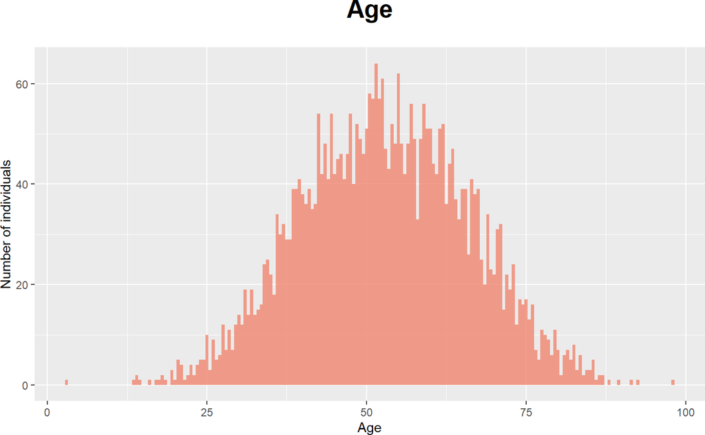

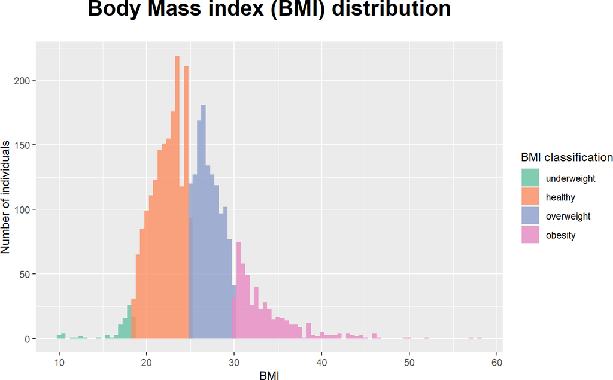

## 2.2 Factor variables

| **Variable** | **Stats / Values** | **Freqs (% of Valid)** | **Graph** | **Missing** |
| --- | --- | --- | --- | --- |
| Biological_Sex [factor] | 1. Female 2. Male | 1524 ( 41.5% ) 2149 ( 58.5% ) |  | 0 (0.0%) |
| Alcohol_Use_per_week [factor] | 1. Never 2. On special occasions 3. Once per week 4. 3-5 times per week 5. Regularly | 668 ( 18.2% ) 1051 ( 28.6% ) 625 ( 17.0% ) 849 ( 23.1% ) 480 ( 13.1% ) |  | 0 (0.0%) |
| Level_of_Education [factor] | 1. Did not complete high sch 2. High school or equivalent 3. Technical or occupational 4. Associate degree 5. Some college coursework c 6. Bachelors degree 7. Masters degree 8. Doctorate (PhD) 9. Prof… | 33 ( 0.9% ) 229 ( 6.2% ) 86 ( 2.3% ) 131 ( 3.6% ) 313 ( 8.5% ) 1306 ( 35.6% ) 797 ( 21.7% ) 157 ( 4.3% ) 621 ( 16.9% ) |  | 0 (0.0%) |
| Caffeine_Use [factor] | 1. Never 2. On sepecial occasions 3. Once per week 4. 3-5 times per week 5. Regularly | 326 ( 9.9% ) 0 ( 0.0% ) 149 ( 4.5% ) 606 ( 18.5% ) 2202 ( 67.1% ) |  | 390 (10.6%) |
| Tobacco_Use [factor] | 1. None 2. Less than 1 cigarette per 3. Less than 1 cigarette per 4. 1-5 cigarettes per day 5. 6-10 cigarettes per day 6. 11-20 cigarettes per day 7. More than 20 cigarettes p | 3510 ( 95.6% ) 51 ( 1.4% ) 26 ( 0.7% ) 30 ( 0.8% ) 23 ( 0.6% ) 22 ( 0.6% ) 11 ( 0.3% ) |  | 0 (0.0%) |
| Recreational_Drug_Frequency [factor] | 1. Never 2. On special occasions 3. Once per week 4. 3-5 times per week 5. Regularly | 57 ( 9.5% ) 300 ( 50.0% ) 63 ( 10.5% ) 93 ( 15.5% ) 87 ( 14.5% ) |  | 3073 (83.7%) |
| Exercise_per_week [factor] | 1. Never 2. 1-2 times per week 3. 3-4 times per week 4. 5-7 times per week 5. 8 or more times per week | 312 ( 8.5% ) 721 ( 19.6% ) 1255 ( 34.2% ) 1262 ( 34.4% ) 123 ( 3.3% ) |  | 0 (0.0%) |
| Hours_of_sleep_per_night [factor] | 1. 5 hours or less 2. 6 hours or less 3. More than 8 hours | 4 ( 0.4% ) 698 ( 66.5% ) 348 ( 33.1% ) |  | 2623 (71.4%) |
| Ethnicity [factor] | 1. Euro 2. Afr_Ame 3. Asia 4. Lati 5. Mid_afr 6. Nat_ame 7. Other 8. Ocea 9. Saha | 2772 ( 75.5% ) 72 ( 2.0% ) 43 ( 1.2% ) 295 ( 8.0% ) 82 ( 2.2% ) 28 ( 0.8% ) 350 ( 9.5% ) 24 ( 0.7% ) 7 ( 0.2% ) |  | 0 (0.0%) |
| Marijuana_frequency [factor] | 1. Never 2. On special occasions 3. Once per week 4. 3-5 times per week 5. Regularly | 3119 ( 88.9% ) 191 ( 5.4% ) 49 ( 1.4% ) 79 ( 2.3% ) 71 ( 2.0% ) |  | 164 (4.5%) |
| BMI_class [factor] | 1. underweight 2. healthy 3. overweight 4. obesity | 90 ( 2.5% ) 1783 ( 48.5% ) 1294 ( 35.2% ) 506 ( 13.8% ) |  | 0 (0.0%) |

Generated by summarytools 1.0.0 ([R](https://www.r-project.org/) version 4.1.2)  
2022-06-29

## 2.3 Logical variables

| Variable | Stats / Values | Freqs (% of Valid) | Graph | Missing |
| --- | --- | --- | --- | --- |
| Asthma [logical] | 1. FALSE 2. TRUE | 3371 (91.8%) 302 ( 8.2%) |  | 0 (0.0%) |
| COPD [logical] | 1. FALSE 2. TRUE | 3664 (99.8%) 9 ( 0.2%) |  | 0 (0.0%) |
| Emphysema [logical] | 1. FALSE 2. TRUE | 3671 (99.9%) 2 ( 0.1%) |  | 0 (0.0%) |
| Stroke [logical] | 1. FALSE 2. TRUE | 3650 (99.4%) 23 ( 0.6%) |  | 0 (0.0%) |
| Tuberculosis [logical] | 1. FALSE 2. TRUE | 3664 (99.8%) 9 ( 0.2%) |  | 0 (0.0%) |
| Cancer_Diagnosis_any [logical] | 1. FALSE 2. TRUE | 3284 (89.4%) 389 (10.6%) |  | 0 (0.0%) |
| Cardiovascular_any [logical] | 1. FALSE 2. TRUE | 2340 (63.7%) 1333 (36.3%) |  | 0 (0.0%) |
| Respiratory_Disease_any [logical] | 1. FALSE 2. TRUE | 3116 (84.8%) 557 (15.2%) |  | 0 (0.0%) |
| Endocrine_Disease_any [logical] | 1. FALSE 2. TRUE | 3064 (83.4%) 609 (16.6%) |  | 0 (0.0%) |
| Skin_Hair_any [logical] | 1. FALSE 2. TRUE | 2358 (64.2%) 1315 (35.8%) |  | 0 (0.0%) |
| Gastrointestinal_any [logical] | 1. FALSE 2. TRUE | 2762 (75.2%) 911 (24.8%) |  | 0 (0.0%) |
| Genito_Urinary_any [logical] | 1. FALSE 2. TRUE | 3041 (82.8%) 632 (17.2%) |  | 0 (0.0%) |
| Musculoskeletal_any [logical] | 1. FALSE 2. TRUE | 3095 (84.3%) 578 (15.7%) |  | 0 (0.0%) |
| Neuropsychological_any [logical] | 1. FALSE 2. TRUE | 2856 (77.8%) 817 (22.2%) |  | 0 (0.0%) |
| Reproductive_any [logical] | 1. FALSE 2. TRUE | 3193 (86.9%) 480 (13.1%) |  | 0 (0.0%) |
| Immune_any [logical] | 1. FALSE 2. TRUE | 3548 (96.6%) 125 ( 3.4%) |  | 0 (0.0%) |
| High_Blood_Pressure [logical] | 1. FALSE 2. TRUE | 3106 (84.6%) 567 (15.4%) |  | 0 (0.0%) |
| High_Cholesterol [logical] | 1. FALSE 2. TRUE | 2915 (79.4%) 758 (20.6%) |  | 0 (0.0%) |
| Anemia [logical] | 1. FALSE 2. TRUE | 3451 (94.0%) 222 ( 6.0%) |  | 0 (0.0%) |
| Heart_Murmur [logical] | 1. FALSE 2. TRUE | 3557 (96.8%) 116 ( 3.2%) |  | 0 (0.0%) |
| Heart_Attack [logical] | 1. FALSE 2. TRUE | 3626 (98.7%) 47 ( 1.3%) |  | 0 (0.0%) |
| Alzheimer [logical] | 1. FALSE 2. TRUE | 3667 (99.8%) 6 ( 0.2%) |  | 0 (0.0%) |
| Anxiety [logical] | 1. FALSE 2. TRUE | 3194 (87.0%) 479 (13.0%) |  | 0 (0.0%) |
| Depression [logical] | 1. FALSE 2. TRUE | 3344 (91.0%) 329 ( 9.0%) |  | 0 (0.0%) |
| Epilepsy [logical] | 1. FALSE 2. TRUE | 3659 (99.6%) 14 ( 0.4%) |  | 0 (0.0%) |
| Migraines [logical] | 1. FALSE 2. TRUE | 3440 (93.7%) 233 ( 6.3%) |  | 0 (0.0%) |
| Chronic_Bronchitis [logical] | 1. FALSE 2. TRUE | 3629 (98.8%) 44 ( 1.2%) |  | 0 (0.0%) |
| Cystic_Fibrosis [logical] | 1. FALSE 2. TRUE | 3668 (99.9%) 5 ( 0.1%) |  | 0 (0.0%) |
| Pneumonia [logical] | 1. FALSE 2. TRUE | 3458 (94.1%) 215 ( 5.9%) |  | 0 (0.0%) |
| Diabetes_1 [logical] | 1. FALSE 2. TRUE | 3658 (99.6%) 15 ( 0.4%) |  | 0 (0.0%) |
| Diabetes_2 [logical] | 1. FALSE 2. TRUE | 3585 (97.6%) 88 ( 2.4%) |  | 0 (0.0%) |
| Prediabetes [logical] | 1. FALSE 2. TRUE | 3524 (95.9%) 149 ( 4.1%) |  | 0 (0.0%) |
| Osteoporosis [logical] | 1. FALSE 2. TRUE | 3590 (97.7%) 83 ( 2.3%) |  | 0 (0.0%) |
| Cirrhosis [logical] | 1. FALSE 2. TRUE | 3668 (99.9%) 5 ( 0.1%) |  | 0 (0.0%) |
| Hepatitis [logical] | 1. FALSE 2. TRUE | 3618 (98.5%) 55 ( 1.5%) |  | 0 (0.0%) |
| Gout [logical] | 1. FALSE 2. TRUE | 3574 (97.3%) 99 ( 2.7%) |  | 0 (0.0%) |
| Rheumatoid_Arthritis [logical] | 1. FALSE 2. TRUE | 3632 (98.9%) 41 ( 1.1%) |  | 0 (0.0%) |
| Cytomegalovirus [logical] | 1. FALSE 2. TRUE | 3646 (99.3%) 27 ( 0.7%) |  | 0 (0.0%) |
| Recreational_Drug_Use_any [logical] | 1. FALSE 2. TRUE | 3100 (84.4%) 573 (15.6%) |  | 0 (0.0%) |
| Amphetamines [logical] | 1. FALSE 2. TRUE | 3640 (99.1%) 33 ( 0.9%) |  | 0 (0.0%) |
| Benzodiazepines [logical] | 1. FALSE 2. TRUE | 3656 (99.5%) 17 ( 0.5%) |  | 0 (0.0%) |
| Marijuana [logical] | 1. FALSE 2. TRUE | 3177 (86.5%) 496 (13.5%) |  | 0 (0.0%) |
| Hallucinogens [logical] | 1. FALSE 2. TRUE | 3575 (97.3%) 98 ( 2.7%) |  | 0 (0.0%) |
| MDMA [logical] | 1. FALSE 2. TRUE | 3611 (98.3%) 62 ( 1.7%) |  | 0 (0.0%) |
| Opioids [logical] | 1. FALSE 2. TRUE | 3666 (99.8%) 7 ( 0.2%) |  | 0 (0.0%) |
| Drug_Alcohol_mother [logical] | 1. FALSE 2. TRUE | 3590 (97.7%) 83 ( 2.3%) |  | 0 (0.0%) |
| Drug_Alcohol_father [logical] | 1. FALSE 2. TRUE | 3461 (94.2%) 212 ( 5.8%) |  | 0 (0.0%) |

## 2.4 Sex differences

| **Biological_Sex** | BMI_class underweight | BMI_class underweight | BMI_class underweight | BMI_class underweight | BMI_class healthy | BMI_class healthy | BMI_class healthy | BMI_class healthy | BMI_class overweight | BMI_class overweight | BMI_class overweight | BMI_class overweight | BMI_class obesity | BMI_class obesity | BMI_class obesity | BMI_class obesity | Total | Total | Total | Total |
| --- | --- | --- | --- | --- | --- | --- | --- | --- | --- | --- | --- | --- | --- | --- | --- | --- | --- | --- | --- | --- |
| **Female** | 76 | ( | 5.0% | ) | 1023 | ( | 67.1% | ) | 288 | ( | 18.9% | ) | 137 | ( | 9.0% | ) | 1524 | ( | 100.0% | ) |
| **Male** | 14 | ( | 0.7% | ) | 760 | ( | 35.4% | ) | 1006 | ( | 46.8% | ) | 369 | ( | 17.2% | ) | 2149 | ( | 100.0% | ) |
| **Total** | 90 | ( | 2.5% | ) | 1783 | ( | 48.5% | ) | 1294 | ( | 35.2% | ) | 506 | ( | 13.8% | ) | 3673 | ( | 100.0% | ) |

**Χ<sup>2</sup>** = 494.2318 **df** = 3 **p** = .0000

Generated by summarytools 1.0.0 ([R](https://www.r-project.org/) version 4.1.2)  
2022-06-29

| **Biological_Sex** | Tobacco_Use None | Tobacco_Use None | Tobacco_Use None | Tobacco_Use None | Tobacco_Use Less than 1 cigarette per week | Tobacco_Use Less than 1 cigarette per week | Tobacco_Use Less than 1 cigarette per week | Tobacco_Use Less than 1 cigarette per week | Tobacco_Use Less than 1 cigarette per day | Tobacco_Use Less than 1 cigarette per day | Tobacco_Use Less than 1 cigarette per day | Tobacco_Use Less than 1 cigarette per day | Tobacco_Use 1-5 cigarettes per day | Tobacco_Use 1-5 cigarettes per day | Tobacco_Use 1-5 cigarettes per day | Tobacco_Use 1-5 cigarettes per day | Tobacco_Use 6-10 cigarettes per day | Tobacco_Use 6-10 cigarettes per day | Tobacco_Use 6-10 cigarettes per day | Tobacco_Use 6-10 cigarettes per day | Tobacco_Use 11-20 cigarettes per day | Tobacco_Use 11-20 cigarettes per day | Tobacco_Use 11-20 cigarettes per day | Tobacco_Use 11-20 cigarettes per day | Tobacco_Use More than 20 cigarettes per day | Tobacco_Use More than 20 cigarettes per day | Tobacco_Use More than 20 cigarettes per day | Tobacco_Use More than 20 cigarettes per day | Total | … |
| --- | --- | --- | --- | --- | --- | --- | --- | --- | --- | --- | --- | --- | --- | --- | --- | --- | --- | --- | --- | --- | --- | --- | --- | --- | --- | --- | --- | --- | --- | --- |
| **Female** | 1455 | ( | 95.5% | ) | 16 | ( | 1.0% | ) | 13 | ( | 0.9% | ) | 13 | ( | 0.9% | ) | 12 | ( | 0.8% | ) | 11 | ( | 0.7% | ) | 4 | ( | 0.3% | ) | 1524 | … |
| **Male** | 2055 | ( | 95.6% | ) | 35 | ( | 1.6% | ) | 13 | ( | 0.6% | ) | 17 | ( | 0.8% | ) | 11 | ( | 0.5% | ) | 11 | ( | 0.5% | ) | 7 | ( | 0.3% | ) | 2149 | … |
| **Total** | 3510 | ( | 95.6% | ) | 51 | ( | 1.4% | ) | 26 | ( | 0.7% | ) | 30 | ( | 0.8% | ) | 23 | ( | 0.6% | ) | 22 | ( | 0.6% | ) | 11 | ( | 0.3% | ) | 3673 | … |

**Χ<sup>2</sup>** = 4.8269 **df** = 6 **p** = .5662

Generated by summarytools 1.0.0 ([R](https://www.r-project.org/) version 4.1.2)  
2022-06-29

| **Biological_Sex** | Recreational_Drug_Frequency Never | Recreational_Drug_Frequency Never | Recreational_Drug_Frequency Never | Recreational_Drug_Frequency Never | Recreational_Drug_Frequency On special occasions | Recreational_Drug_Frequency On special occasions | Recreational_Drug_Frequency On special occasions | Recreational_Drug_Frequency On special occasions | Recreational_Drug_Frequency Once per week | Recreational_Drug_Frequency Once per week | Recreational_Drug_Frequency Once per week | Recreational_Drug_Frequency Once per week | Recreational_Drug_Frequency 3-5 times per week | Recreational_Drug_Frequency 3-5 times per week | Recreational_Drug_Frequency 3-5 times per week | Recreational_Drug_Frequency 3-5 times per week | Recreational_Drug_Frequency Regularly | Recreational_Drug_Frequency Regularly | Recreational_Drug_Frequency Regularly | Recreational_Drug_Frequency Regularly | Recreational_Drug_Frequency <NA> | Recreational_Drug_Frequency <NA> | Recreational_Drug_Frequency <NA> | Recreational_Drug_Frequency <NA> | Total | Total | Total | Total |
| --- | --- | --- | --- | --- | --- | --- | --- | --- | --- | --- | --- | --- | --- | --- | --- | --- | --- | --- | --- | --- | --- | --- | --- | --- | --- | --- | --- | --- |
| **Female** | 26 | ( | 1.7% | ) | 101 | ( | 6.6% | ) | 17 | ( | 1.1% | ) | 20 | ( | 1.3% | ) | 32 | ( | 2.1% | ) | 1328 | ( | 87.1% | ) | 1524 | ( | 100.0% | ) |
| **Male** | 31 | ( | 1.4% | ) | 199 | ( | 9.3% | ) | 46 | ( | 2.1% | ) | 73 | ( | 3.4% | ) | 55 | ( | 2.6% | ) | 1745 | ( | 81.2% | ) | 2149 | ( | 100.0% | ) |
| **Total** | 57 | ( | 1.6% | ) | 300 | ( | 8.2% | ) | 63 | ( | 1.7% | ) | 93 | ( | 2.5% | ) | 87 | ( | 2.4% | ) | 3073 | ( | 83.7% | ) | 3673 | ( | 100.0% | ) |

**Χ<sup>2</sup>** = 11.3423 **df** = 4 **p** = .0230

Generated by summarytools 1.0.0 ([R](https://www.r-project.org/) version 4.1.2)  
2022-06-29

# 3 Metadata saving

The variables contained in the final metadata file are the following:

| Variable | Class | Examples |
| --- | --- | --- |
| PatientID | character | 101234567890_R01C01 / 123456789101_R01C01 / 204220340049_R01C01 |
| PID | numeric | 118724 (87689-125749) |
| Weight | numeric | 170 (12-376) |
| Height | character | 5 ft, 1 in / 1 ft, 1 in / 6 ft, 4 in |
| Zip_Code | character | 40503 / 89128 / 21076 |
| Birth_Country | character | USA / florida / colombia |
| Biological_Sex | factor | Female / Male |
| Ethnicity_Ancestry | character | European or Caucasian / Asian (e.g. Chinese, Indian, Kazakh, Thai) / Latino or Hispanic; European or Caucasian; Middle Eastern or North African |
| Blood_Type | character | O Negative / A Negative / O Postive |
| Cancer_Diagnosis | character | No / skin cancer / melanoma |
| Genetic_Variant | character | None of the above / BRCA1/BRCA2 / Im not sure |
| Cardiovascular | character | n/a / High Blood Pressure / High Cholesterol |
| Respiratory_Disease | character | Asthma / Sleep Apnea / Pneumonia |
| Endocrine_Disease | character | n/a / Hashimotos Thyroiditis / Prediabetes |
| Alcohol_Use_per_week | factor | Once per week / On special occasions / Regularly |
| Skin_Hair | character | None / Eczema / Eczema; Loss of Hair |
| Age_for_Loss_of_Hair | numeric | 1 (0-73) |
| Gastrointestinal | character | n/a / Crohns Disease / Gastroesophageal Reflux Disease (GERD) |
| Genito_Urinary | character | n/a / Urinary Incontinence; Urinary Tract Infections (UTI) / Kidney Stones |
| Musculoskeletal | character | n/a / Gout / Osteoarthritis |
| Neuropsychological | character | n/a / Depression; Migraines / Traumatic Brain Injury (TBI) |
| Reproductive | character | n/a / Enlarged Prostate/Benign Prostate Hyperplasia (BPH) / Endometriosis |
| Immune | character | n/a / linear sclerodderma / Lupus |
| Menopause | character | No / Yes |
| Given_Birth | character | No / Yes |
| Mother_Nicotine_Use | character | No / Yes / Unknown |
| Mother_Pregnancy_Complications | character | No / Yes / Unknown |
| Nutritional_Supplements | character | Digestive support: probiotic, digestive enzymes, etc.; Herbal supplements; Antioxidants: coenzyme Q10, green tree extract, resveratrol, etc.; Vitamins; Fish oil/Omega fatty acids; Minerals, calcium, i… |
| Supplements_Medication | character | Resveratrol / Metformin; Dehydroepiandrosterone (DHEA) / Dehydroepiandrosterone (DHEA) |
| Actively_engage_in_anti_aging_interventions | character | Hormone replacement therapy / Stem cell therapy; Hormone replacement therapy; NAD therapy / NAD therapy |

[output cut: 90 more lines]

Finally, we save the metadata in a “.Rdata” and “.csv files with the variables transformed.

```r
save(metadata, file="G:/TruDiagnostic/metadata/metadata.Rdata")
write.csv2(data.frame(metadata),"G:/TruDiagnostic/metadata/metadata.csv", row.names = F)
```